# Session 7

## Session outline

1. Web Scraping
1. What is HTML?
- Basic HTML Structure
- HTML Elements
- How to select paths
1. Basic R packages for web scraping
- `rvest` package
- `RSelenium` package
- `httr` package
2. Requesting Data from an API

## Web Scraping

### What is HTML?

- Standard markup language for constructing web pages
- HTML describes the `structure` of a Web page
- HTML consists of a series of `elements`
- HTML cam be enhanced by [`CSS`](https://www.w3schools.com/css/default.asp) and [`JavaScript`](https://www.w3schools.com/js/default.asp)

CSS is used to style an HTML document (e.g. presentation, formatting and layout)

JavaScript is the programming language of the web (controls the behavior of elements)

## Web Scraping

### HTML Structure

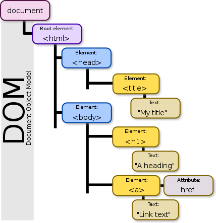

Image source

```r
<!DOCTYPE html>  # Declaration
<HTML>           # Root of HTML doc
    <HEAD>       # Metadata
        <TITLE>My Title</TITLE>
    </HEAD>
    <BODY>      # contents
        <H1>A Heading</H1>
        <a href="path">Link text</a>
    </BODY>
</HTML>
```

## Web Scraping

### HTML Element

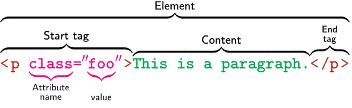

[List of Common HTML Tags](https://www.w3schools.com/tags/tag_comment.asp)

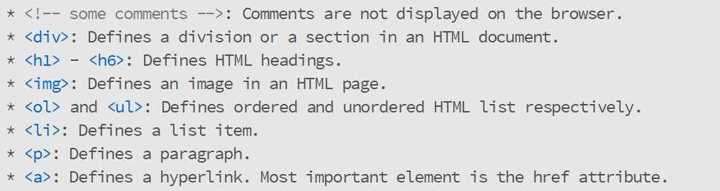

Also check the `table` tag

## Web Scraping

### Your Turn – Create an HTML page

1. Open a text editor – e.g. Windows Notepad
2. Declare HTML document – 1st line of your document

```r
<!DOCTYPE html>
```

3. Insert the following tags: html, head, and body

```r
<!DOCTYPE html>
<html>
  <head>
  </head>
  <body>
  </body>
</html>
```

[Download the complete document](https://rworkshop-at-uf.github.io/session7/html_example.html)

## Web Scraping

### Your Turn – Create an HTML page (Cont.)

4. Insert `title` tag under `head` tag

```r
<head>
  <title>HTML Tutorial</title>
</head>
```

5. Create a division/section using `div` tag under the `body` tag

```r
<body>
  <h1>This is H1 tag</h1>
  <p>This is a paragraph</p>
  <div>
    <h2>div H2 heading</h2>
  </div>
</body>
```

## Web Scraping

### Your Turn – Create an HTML page (Cont.)

6. Create an anchor with `a` tag.  
   Use `href` attribute to hyperlink  
   “https://rworkshop-at-uf.github.io/schedule.html”

```r
<body>
  <a href="https://rworkshop-at-uf.github.io/schedule.html">Schedules</a>
</body>
```

## Web Scraping

### Your Turn – Create an HTML page (Cont.)

7. Create a table with `table` tag

   – You may also define `thead` and `tbody`

```r
<table>
  <tr>                           # `tr`: table row
    <th>COL<sub>1</sub></th>     # `th`: table header
    <th>COL<sub>2</sub></th>
  </tr>
  <tr>
    <td>cell<sub>11</sub></td>   # `td`: table data
    <td>cell<sub>12</sub></td>
  </tr>
  <tr>
    <td>cell<sub>21</sub></td>
    <td>cell<sub>22</sub></td>
  </tr>
</table>
```

## Web Scraping

### Your Turn – Create an HTML page (Cont.)

8. Add JavaScript with `script` tag

```r
# JavaScript for displaying current time
<script type="text/javascript">
  function updateTime() {
      var currentTime = new Date();
      var hours = currentTime.getHours();
      var minutes = currentTime.getMinutes();
      var seconds = currentTime.getSeconds();
      var v = hours + ":" + minutes + ":" + seconds + " ";
      setTimeout("updateTime()",1000);
      document.getElementById('time').innerHTML=v;
  }
</script>
<button onclick="updateTime()">Click to get time</button>
<h4>Current Time: <span id="time"></h4>
```

## Web Scraping

### How to select paths – xpath

1. XPath uses “path like” syntax to identify and navigate node(s)
2. There are 7 kind of nodes – e.g. element, attribute, text, etc.
3. Syntax – Selecting Nodes

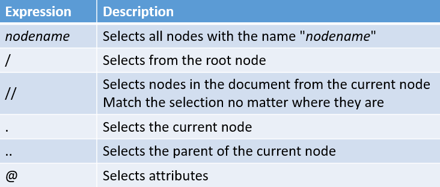

[Source](https://www.w3schools.com/xml/xpath_syntax.asp)

## Web Scraping

### How to select paths – xpath (Cont.)

2. Syntax – Predicates
- Predicates are used to find a specific node(s)
- Predicates are embedded in square brackets
3. Syntax – Axes
- Axes represents a relationship to the (current) node

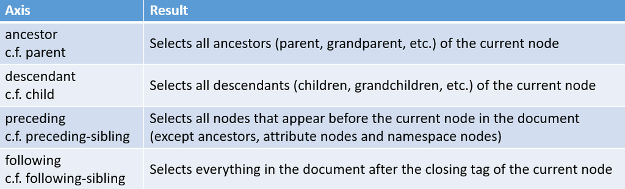

## Web Scraping

### How to select paths – xpath (Cont.)

Example

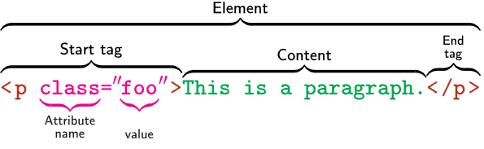

`//p [@class="foo"]`  
`//p [contains(@class, "f")]`  
`//p [contains(text(),'paragraph')]`

## Web Scraping

### rvest

1. Load `rvest`

```r
#install.packages("rvest")
library(rvest)
```

2. `read_html()`

Create an html document from a URL, a string, or a file containing html

```r
read_html("some url")
```

3. `html_nodes()`

Two important arguments

- Either a document or a node (set)
- Path in `xpath` or `css`

```r
html_nodes(document, css=path)
html_nodes(document, xpath=path)
```

## Web Scraping

### `rvest` (Cont.)

4. Extract Components
- `html_text()`

Extract all text inside the tag

- `html_attr()`

Extract contents of a single attribute

- `html_attrs()`

Extract all attributes

- `html_table()`

Parse tables into data frames

- `html_name()`

Extract the name(s) of the tag(s)

5. Combine the steps

```
"some url" %>%
  read_html() %>%
  html_nodes(xpath="some path") %>%
  html_`component`()
```